# Concrete Case Study

Load up libraries and set up parallel processing

```r
library("AppliedPredictiveModeling")
library("Hmisc")
library("caret")
library("Cubist")
library("plyr")
library("dplyr")
library("reshape2")
library("doMC")
trellis.par.set(caretTheme())
registerDoMC(cores = 4)
```

Load the data up and have a look

```r
data(concrete)
str(concrete)
```

```
## 'data.frame':    1030 obs. of  9 variables:
##  $ Cement             : num  540 540 332 332 199 ...
##  $ BlastFurnaceSlag   : num  0 0 142 142 132 ...
##  $ FlyAsh             : num  0 0 0 0 0 0 0 0 0 0 ...
##  $ Water              : num  162 162 228 228 192 228 228 228 228 228 ...
##  $ Superplasticizer   : num  2.5 2.5 0 0 0 0 0 0 0 0 ...
##  $ CoarseAggregate    : num  1040 1055 932 932 978 ...
##  $ FineAggregate      : num  676 676 594 594 826 ...
##  $ Age                : int  28 28 270 365 360 90 365 28 28 28 ...
##  $ CompressiveStrength: num  80 61.9 40.3 41 44.3 ...
```

```r
# mixtures has mixture proportions
str(mixtures)
```

```
## 'data.frame':    1030 obs. of  9 variables:
##  $ Cement             : num  0.2231 0.2217 0.1492 0.1492 0.0853 ...
##  $ BlastFurnaceSlag   : num  0 0 0.0639 0.0639 0.0569 ...
##  $ FlyAsh             : num  0 0 0 0 0 0 0 0 0 0 ...
##  $ Water              : num  0.0669 0.0665 0.1023 0.1023 0.0825 ...
##  $ Superplasticizer   : num  0.00103 0.00103 0 0 0 ...
##  $ CoarseAggregate    : num  0.43 0.433 0.418 0.418 0.42 ...
##  $ FineAggregate      : num  0.279 0.278 0.266 0.266 0.355 ...
##  $ Age                : int  28 28 270 365 360 90 365 28 28 28 ...
##  $ CompressiveStrength: num  80 61.9 40.3 41 44.3 ...
```

```r
describe(mixtures)
```

```
## mixtures
##
##  9  Variables      1030  Observations
## ---------------------------------------------------------------------------
## Cement
##       n missing  unique    Info    Mean     .05     .10     .25     .50
##    1030       0     422       1  0.1196 0.06317 0.06734 0.08206 0.11528
##     .75     .90     .95
## 0.14917 0.18222 0.20509
##
## lowest : 0.04482 0.04789 0.05082 0.05405 0.05749
## highest: 0.22172 0.22309 0.22374 0.22540 0.22541
## ---------------------------------------------------------------------------
## BlastFurnaceSlag
##        n  missing   unique     Info     Mean      .05      .10      .25
##     1030        0      243      0.9  0.03164 0.000000 0.000000 0.000000
##      .50      .75      .90      .95
## 0.009455 0.061972 0.082769 0.102002
##
## lowest : 0.000000 0.004773 0.005709 0.006615 0.006620
## highest: 0.124250 0.132411 0.132882 0.143384 0.150339
## ---------------------------------------------------------------------------
## FlyAsh
##       n missing  unique    Info    Mean     .05     .10     .25     .50
##    1030       0     214    0.83 0.02317 0.00000 0.00000 0.00000 0.00000
##     .75     .90     .95
## 0.05034 0.06118 0.07080
##
## lowest : 0.00000 0.01014 0.01031 0.01031 0.02441
## highest: 0.08607 0.08877 0.08880 0.08881 0.08884
## ---------------------------------------------------------------------------
## Water
##       n missing  unique    Info    Mean     .05     .10     .25     .50
##    1030       0     406       1 0.07773 0.06006 0.06395 0.06954 0.07862
##     .75     .90     .95
## 0.08386 0.08938 0.10229
##
## lowest : 0.05139 0.05205 0.05259 0.05272 0.05627
## highest: 0.10340 0.10769 0.10773 0.11216 0.11222
## ---------------------------------------------------------------------------
```

[output cut: 31 more lines]

```
##      56     100     180
##
##           1   3   7 14  28 56 90 91 100 120 180 270 360 365
## Frequency 2 134 126 62 425 91 54 22  52   3  26  13   6  14
## %         0  13  12  6  41  9  5  2   5   0   3   1   1   1
## ---------------------------------------------------------------------------
## CompressiveStrength
##       n missing  unique    Info    Mean     .05     .10     .25     .50
##    1030       0     845       1   35.82   10.96   14.20   23.71   34.45
##     .75     .90     .95
##   46.14   58.82   66.80
##
## lowest :  2.33  3.32  4.57  4.78  4.83
## highest: 79.40 79.99 80.20 81.75 82.60
## ---------------------------------------------------------------------------
```

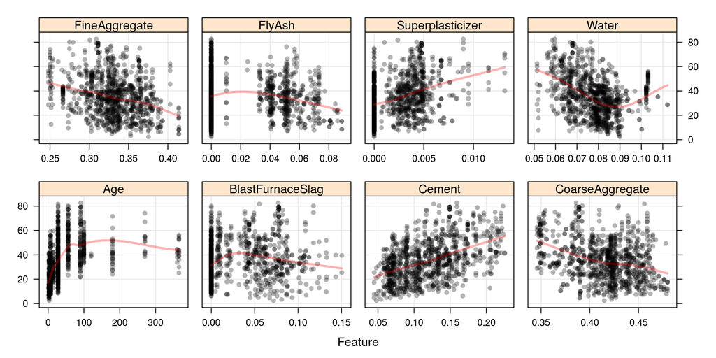

```r
# need to play with eg transparent points for overplotting
# how make smooth line different transparency?
featurePlot(x = mixtures[, -9],
            y = mixtures$CompressiveStrength,
            # space between panels
            between = list(x = 1, y = 1),
            type = c("g", "p", "smooth"),
            col.line = 'red',
            lwd = 3,
            pch = 16,
            alpha = 0.3,
            col = 'black'
            )
```

Below, we want to average replicated mixtures and train test split.

```r
averaged <- ddply(mixtures,
                  .(Cement, BlastFurnaceSlag, FlyAsh, Water,
                    Superplasticizer, CoarseAggregate,
                    FineAggregate, Age),
                  function(x) c(CompressiveStrength =
                                  mean(x$CompressiveStrength)))

# or alternatively use dplyr?
averaged2 <- mixtures %>%
  group_by(Cement, BlastFurnaceSlag, FlyAsh, Water,
                    Superplasticizer, CoarseAggregate,
                    FineAggregate, Age) %>%
  summarise(CompressiveStrength = mean(CompressiveStrength))

# train test split
set.seed(975)
forTrain <- createDataPartition(averaged$CompressiveStrength,
                                p = 0.75,
                                list = F)

training <- averaged[forTrain, ]
testing <- averaged[-forTrain, ]
```

```r
# use custom function to get quadratic and two-factor interactions
# remember outcome in in 9th column!
interactionTrain <- quadInteraction(training[1:8])
interactionTest <- quadInteraction(testing[1:8])

interactionTrain$CompressiveStrength <- training$CompressiveStrength
interactionTest$CompressiveStrength <- testing$CompressiveStrength
```

We chose to use repeated 10-fold cross validation:

```r
controlObject <- trainControl(method = "repeatedcv",
                              repeats = 5,
                              number = 10)
```

Start with linear models

```r
set.seed(669)
linearReg <- train(CompressiveStrength ~ .,
                   data = interactionTrain,
                   method = "lm",
                   trControl = controlObject)
linearReg
```

```
## Linear Regression
##
## 745 samples
##  44 predictors
##
## No pre-processing
## Resampling: Cross-Validated (10 fold, repeated 5 times)
##
## Summary of sample sizes: 670, 671, 671, 672, 671, 669, ...
##
## Resampling results
##
##   RMSE      Rsquared   RMSE SD    Rsquared SD
##   7.780881  0.7742653  0.8821679  0.05248533
##
##
```

```r
set.seed(669)
plsModel <- train(CompressiveStrength ~ .,
                  data = interactionTrain,
                  method = "pls",
                  preProc = c("center", "scale"),
                  tuneLength = 15,
                  trControl = controlObject)
plsModel
```

```
## Partial Least Squares
##
## 745 samples
##  44 predictors
##
## Pre-processing: centered, scaled
## Resampling: Cross-Validated (10 fold, repeated 5 times)
##
## Summary of sample sizes: 670, 671, 671, 672, 671, 669, ...
##
## Resampling results across tuning parameters:
##
##   ncomp  RMSE       Rsquared   RMSE SD    Rsquared SD
##    1     10.683020  0.5731516  0.7190107  0.06127402
##    2      9.848604  0.6399878  0.9590017  0.05906699
##    3      9.202660  0.6838310  0.8143753  0.05362957
##    4      8.790707  0.7103136  0.8524873  0.05952708
##    5      8.619154  0.7221647  0.8469751  0.05663941
##    6      8.532484  0.7283746  0.8569347  0.05474427
##    7      8.349819  0.7407053  0.8112248  0.05056434
##    8      8.235489  0.7483731  0.8146758  0.04827009
##    9      7.991071  0.7608628  0.8580371  0.05201628
##   10      7.840972  0.7703750  0.8329605  0.04872683
##   11      7.784160  0.7737346  0.8485819  0.04784778
##   12      7.760246  0.7753312  0.8430306  0.04698850
##   13      7.740246  0.7764619  0.8419179  0.04742286
##   14      7.763937  0.7756907  0.8007886  0.04636174
##   15      7.755023  0.7757621  0.8552894  0.04992741
##
## RMSE was used to select the optimal model using  the smallest value.
## The final value used for the model was ncomp = 13.
```

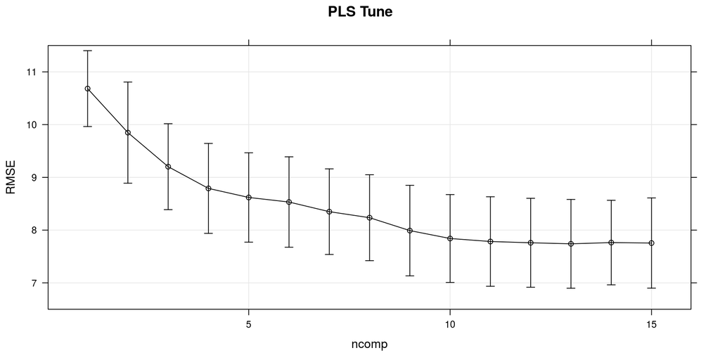

```r
enetGrid <- expand.grid(lambda = c(0, 0.01, 0.1, 0.1),
                        fraction = seq(0.05, 1, length = 20))
set.seed(669)
enetModel <- train(CompressiveStrength ~ .,
                  data = interactionTrain,
                  method = "enet",
                  preProc = c("center", "scale"),
                  tuneGrid = enetGrid,
                  trControl = controlObject)
```

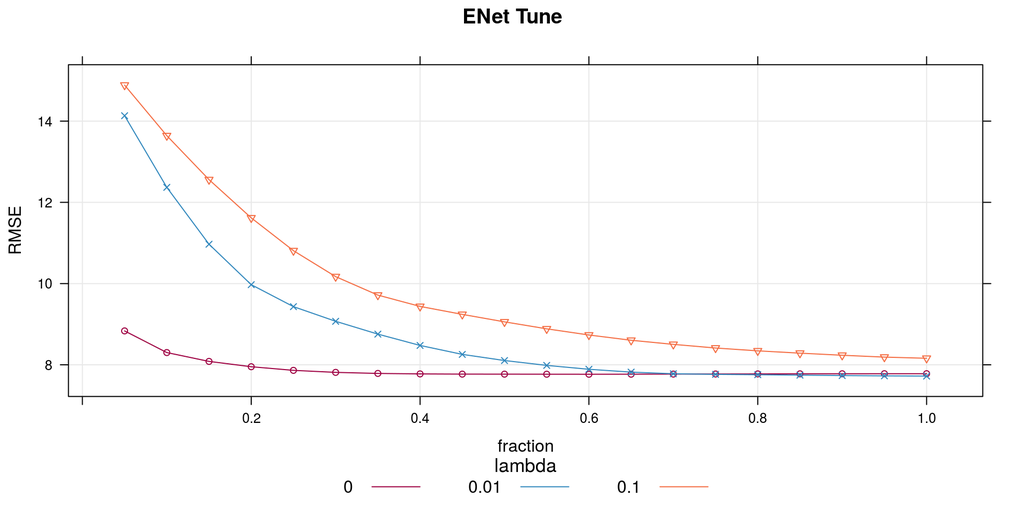

Now we go to nonlinear models: MARS, neural nets and SVM’s. Note that we no longer need to include data with interation terms, as the models are nonlinear

```r
# For earth, no preprocessing needed.
# tune over degree and nprune.
# Note we assume degree = 1 as can get unstable
# beyond this

earthGrid <- expand.grid(degree = 1,
                         nprune = 2:25)
set.seed(669)
earthModel <- train(CompressiveStrength ~ .,
                    data = training,
                    method = "earth",
                    tuneGrid = earthGrid,
                    trControl = controlObject)
```

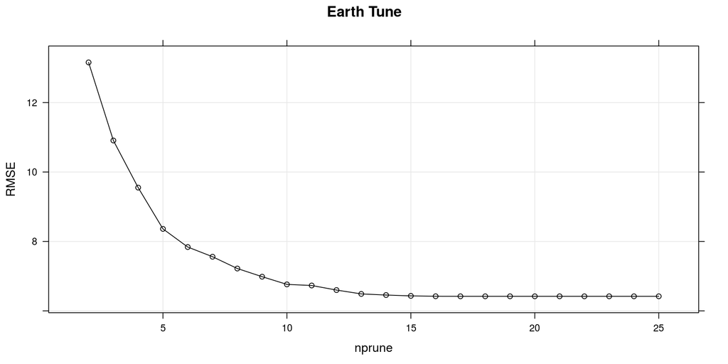

```r
# radial basis SVM. Need to center and scale for
# preprocess
# Tune over c (penalty?)

svmRModel <- train(CompressiveStrength ~ .,
                   data = training,
                   method = "svmRadial",
                   preProc = c("center", "scale"),
                   tuneLength = 15,
                   trControl = controlObject)
```

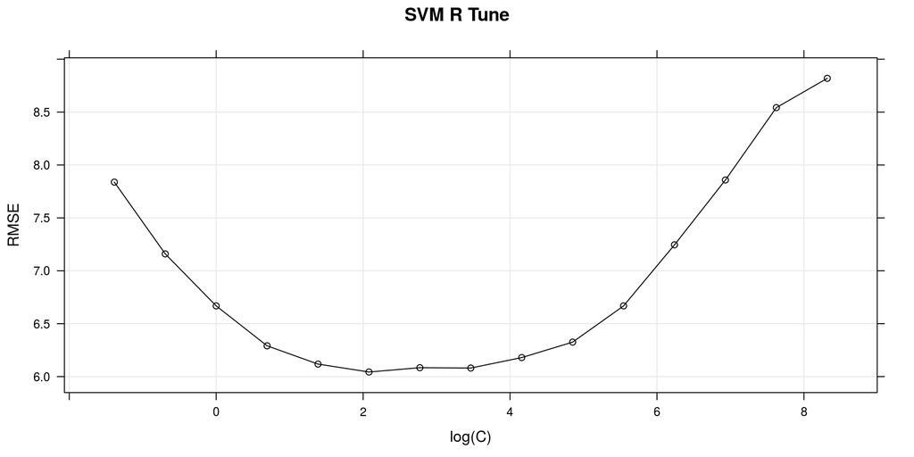

```r
nnetGrid <- expand.grid(decay = c(0.001, 0.01, 0.1),
                        size = seq(1, 27, by = 2),
                        bag = FALSE)
set.seed(669)
nnetModel <- train(CompressiveStrength ~ .,
                   data = training,
                   method = "avNNet",
                   preProc = c("center", "scale"),
                   tuneGrid = nnetGrid,
                   linout = T,
                   trace = F,
                   maxit = 1000,
                   trControl = controlObject)
```

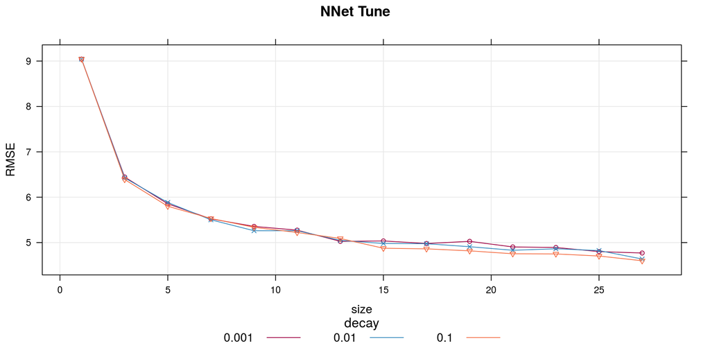

Now some tree based models:

```r
# CART trees - tuning over complexity parameter
set.seed(669)
rpartModel <- train(CompressiveStrength ~ .,
                    data = training,
                    method = "rpart",
                    tuneLength = 30,
                    trControl = controlObject)
```

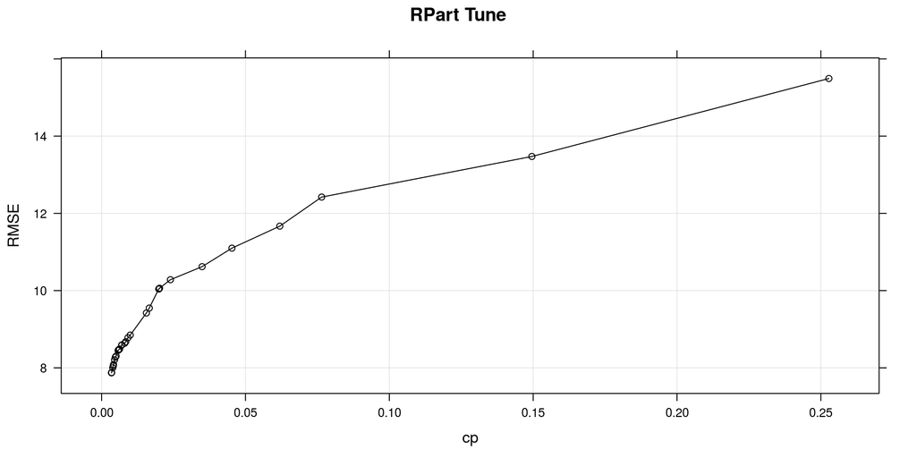

```r
# conditional inference tree - tuning over min criterion for split
set.seed(669)
ctreeModel <- train(CompressiveStrength ~ .,
                    data = training,
                    method = "ctree",
                    tuneLength = 10,
                    trControl = controlObject)
```

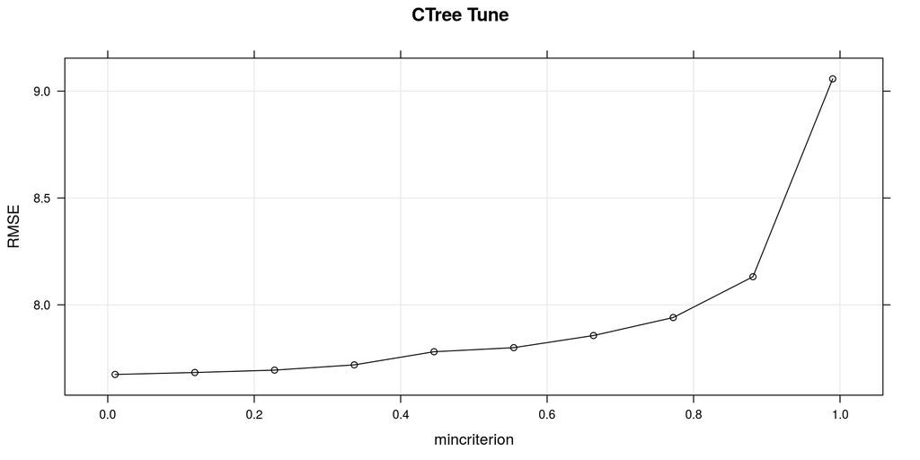

```r
# rule based tree
# may get pissy using multicores
detach("package:doMC", unload = T)
set.seed(669)
mtModel <- train(CompressiveStrength ~ .,
                 data = training,
                 method = "M5",
                 trControl = controlObject)
```

Final set of complex models

```r
# reset multi core processing
library("doMC")
registerDoMC(cores = 4)
```

```r
# random forest
# this is tuning over mtry
# no need to preprocess!
set.seed(669)
rfModel <- train(CompressiveStrength ~ .,
                 data = training,
                 method = "rf",
                 tuneLength = 7,
                 ntrees = 1000,
                 importance = TRUE,
                 trControl = controlObject)
```

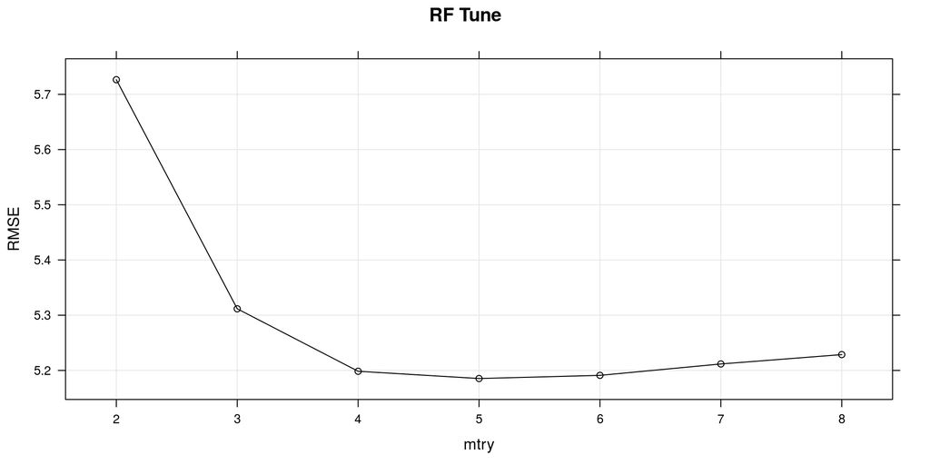

```r
# bagged trees
set.seed(669)
bagTreeModel <- train(CompressiveStrength ~ .,
                      data = training,
                      method = "treebag",
                      trControl = controlObject)
```

```
## Bagged CART
##
## 745 samples
##   8 predictors
##
## No pre-processing
## Resampling: Cross-Validated (10 fold, repeated 5 times)
##
## Summary of sample sizes: 670, 671, 671, 672, 671, 669, ...
##
## Resampling results
##
##   RMSE     Rsquared   RMSE SD    Rsquared SD
##   7.53381  0.7974797  0.7118242  0.03817816
##
##
```

```r
# boosted trees
gbmGrid <- expand.grid(interaction.depth = seq(1, 7, by = 2),
                       n.trees = seq(100, 1000, by = 50),
                       shrinkage = c(0.01, 0.1),
                       n.minobsinnode = 10)

set.seed(669)
gbmModel <- train(CompressiveStrength ~ .,
                  data = training,
                  method = "gbm",
                  tuneGrid = gbmGrid,
                  verbose = FALSE,
                  trControl = controlObject)
```

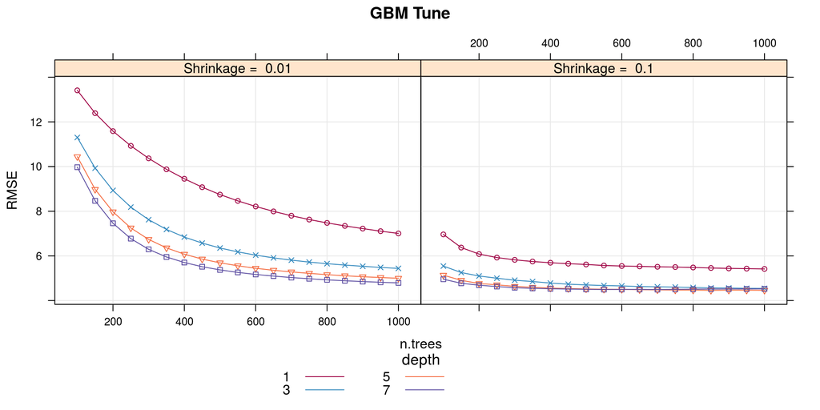

```r
cubistGrid <- expand.grid(committees = c(1, 5, 10, 50, 75, 100),
                          neighbors = c(0, 1, 3, 5, 7, 9))
set.seed(669)
cubistModel <- train(CompressiveStrength ~ .,
                 data = training,
                 method = "cubist",
                 tuneGrid = cubistGrid,
                 trControl = controlObject)
```

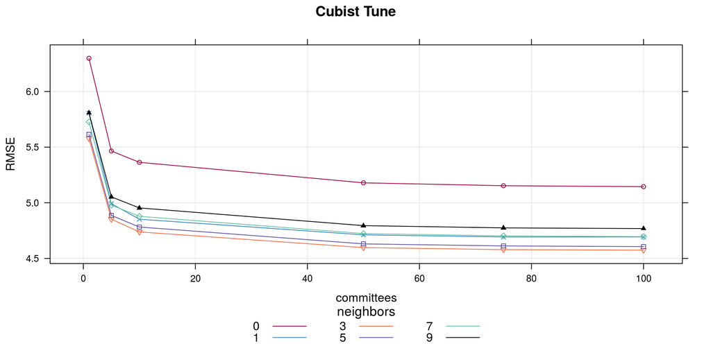

Ok, now we have models tuned. Lets look at resamples to get an idea of accuracy

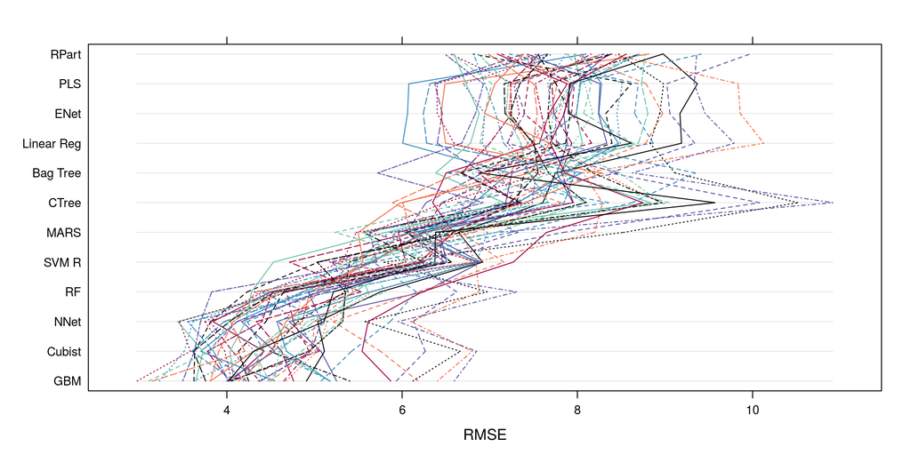

```r
allResamples <- resamples(list("Linear Reg" = linearReg,
                               "PLS" = plsModel,
                               "ENet" =  enetModel,
                               "MARS" = earthModel,
                               "SVM R" = svmRModel,
                               "NNet" = nnetModel,
                               "RPart" = rpartModel,
                               "CTree" = ctreeModel,
                               "RF" = rfModel,
                               "Bag Tree" = bagTreeModel,
                               "GBM" = gbmModel,
                               "Cubist" = cubistModel))

parallelplot(allResamples)
```

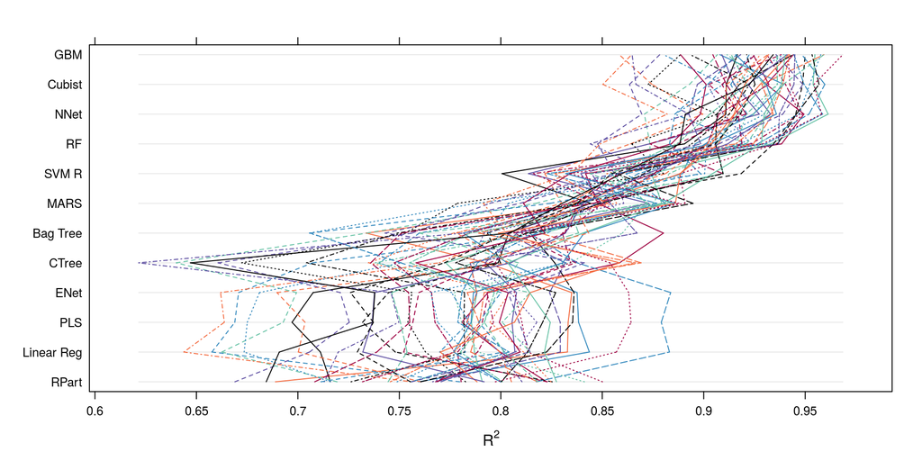

```r
parallelplot(allResamples, metric = "Rsquared")
```

## Predictions

chose the 4 best models: cubist, gbm, random forest and neural net

```r
rfPredictions <- predict(rfModel, testing[, 1:8])
gbmPredictions <- predict(gbmModel, testing[, 1:8])
cubistPredictions <- predict(cubistModel, testing[, 1:8])
nnetPredictions <- predict(nnetModel, testing[, 1:8])
```

```r
predictions <- data.frame(rf = rfPredictions,
                          gbm = gbmPredictions,
                          cubist = cubistPredictions,
                          nnet = nnetPredictions,
                          compressiveStrength = testing[, 9])

lapply(predictions[, 1:4], postResample, obs = predictions$compressiveStrength)
```

```
## $rf
##      RMSE  Rsquared
## 5.0825083 0.9055083
##
## $gbm
##      RMSE  Rsquared
## 4.1728185 0.9342204
##
## $cubist
##      RMSE  Rsquared
## 4.4195775 0.9257341
##
## $nnet
##      RMSE  Rsquared
## 4.6511884 0.9180605
```

```r
# just out of interest, crudely stack the models. Would be interesting
# to try with weighted means, and weight differently in different quartiles
# of predicted response? Eg we can see nnet is very poor above predicted = 60,
# so give it less weight here
combinedPred <- 0.25 * rowSums(predictions[1:4])
postResample(combinedPred, obs = predictions$compressiveStrength)
```

```
##      RMSE  Rsquared
## 4.1225185 0.9356954
```

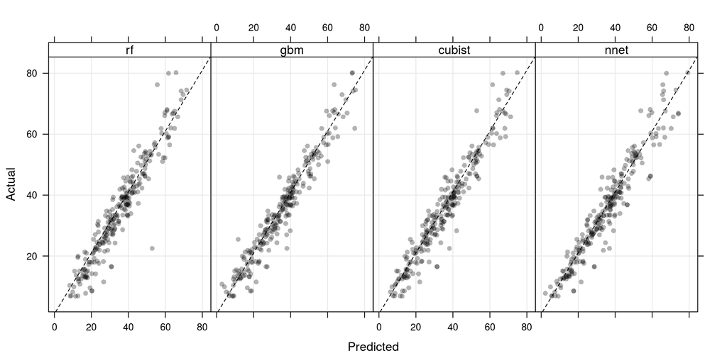

To predict optimal mixtures, we first use the 28-day data to generate a set of random starting points from the training set. Since distances between the formulations will be used as a measure of dissimilarity, the data are pre-processed to have the same mean and variance for each predictor. After this, a single random mixture is selected to initialize the maximum dissimilarity sampling process

```r
age28Data <- subset(training, Age == 28)
# remove age and compressive strength, preprocess so
# centered and scaled
pp1 <- preProcess(age28Data[, -(8:9)], c("center", "scale"))
scaledTrain <- predict(pp1, age28Data[1:7])

set.seed(669)
# sample one mixture (startMixture returns a row number,
# starters is the start mixture)
startMixture <- sample(1:nrow(age28Data), 1)
starters <- scaledTrain[startMixture, 1:7]
```

Now use maximum dissimilarity sampling to select 14 more mixtures to get a diverse set of starting points for search algorithms:

```r
pool <- scaledTrain
index <- maxDissim(starters, pool, 14)
startPoints <- c(startMixture, index)
starters <- age28Data[startPoints, 1:7]
# we now have 15 starting points for optimisation search
```

Since all seven mixtures add to one, the search prcedure will conduct the search without one ingredient (water): this will be detemrined by the sum of the other six ingredient proportions. Without this, candidate mixtures would be selected that do not add to one

```r
startingValues <- starters[, names(starters) != 'Water']
```

Want to use optim() to maximise compressinve strength. A custom function is needed to translate a candidate mixture into a predictions. This function can find settings to minimize a function, so it will return the negative of the compressive strength.

```r
# takes 6 sample propertions in x (not water!)
# and the model used for prediction
modelPrediction <- function(x, model) {
  # checks that proprtions are between 0 and 1
  # checks that proprtion of water does not fall below 5%

  # check proportions in correct range
  # length(x) -1 rather than hard code 6?
  for(i in 1:6) {
    if(x[i] < 0 | x[i] > 1) return(10^38)
  }

  # determine water proportion
  x <- c(x, 1 - sum(x))

  # check water range
  if(x[7] < 0.05) return(10^38)

  # transpose then convert vector to data frame
  #and fix age to 28 days
  tmp <- as.data.frame(t(x))
  names(tmp) <- c('Cement', 'BlastFurnaceSlag',
                  'FlyAsh', 'Superplasticizer',
                  'CoarseAggregate', 'FineAggregate',
                  'Water')
  tmp$Age <- 28

  # get the model prediction
  # multiply by -1 as optim will return
  # minimum of function
  predict(model, tmp) * -1
}
```

First, use Cubist

```r
cubistResults <- startingValues
cubistResults$Water <- NA
cubistResults$Prediction <- NA

for(i in 1: nrow(cubistResults)) {
  results <- optim(unlist(cubistResults[i, 1:6]),
                   modelPrediction,
                   method = "Nelder-Mead",
                   control = list(maxit=5000),
                   model = cubistModel)

  cubistResults$Prediction[i] <- -results$value
  cubistResults[i, 1:6] <- results$par
}

cubistResults$Water <- 1- apply(cubistResults[, 1:6], 1, sum)
# top 3
cubistResults <- cubistResults[order(-cubistResults$Prediction), ][1:3, ]
cubistResults$Model <- "Cubist"

cubistResults
```

```
##        Cement BlastFurnaceSlag       FlyAsh Superplasticizer
## 886 0.2170775       0.49990071 8.875196e-06      0.003637078
## 881 0.5175164       0.41166478 1.031139e-02      0.006540238
## 10  0.2180098       0.04066479 2.872112e-03      0.004969352
##     CoarseAggregate FineAggregate      Water Prediction  Model
## 886    4.483899e-02  1.835336e-01 0.05100325  127.05808 Cubist
## 881    7.361503e-07  3.291583e-07 0.05396608  122.09354 Cubist
## 10     4.147334e-01  2.687505e-01 0.05000002   86.98502 Cubist
```

Neural net:

```r
nnetResults <- startingValues
nnetResults$Water <- NA
nnetResults$Prediction <- NA

for(i in 1: nrow(nnetResults)) {
  results <- optim(unlist(nnetResults[i, 1:6]),
                   modelPrediction,
                   method = "Nelder-Mead",
                   control = list(maxit=5000),
                   model = nnetModel)

  nnetResults$Prediction[i] <- -results$value
  nnetResults[i, 1:6] <- results$par
}

nnetResults$Water <- 1- apply(nnetResults[, 1:6], 1, sum)
# top 3
nnetResults <- nnetResults[order(-nnetResults$Prediction), ][1:3, ]
nnetResults$Model <- "NNet"

nnetResults
```

```
##        Cement BlastFurnaceSlag       FlyAsh Superplasticizer
## 122 0.2452615       0.07604522 5.109982e-10     0.0004128946
## 10  0.2174466       0.06600313 1.950301e-03     0.0018976682
## 69  0.1520883       0.14233295 4.884204e-07     0.0025566530
##     CoarseAggregate FineAggregate      Water Prediction Model
## 122       0.3304836     0.2960981 0.05169872   90.70154  NNet
## 10        0.3980041     0.2596177 0.05508043   90.49722  NNet
## 69        0.3877399     0.2568001 0.05848163   88.28699  NNet
```

gbm:

```r
gbmResults <- startingValues
gbmResults$Water <- NA
gbmResults$Prediction <- NA

for(i in 1: nrow(gbmResults)) {
  results <- optim(unlist(gbmResults[i, 1:6]),
                   modelPrediction,
                   method = "Nelder-Mead",
                   control = list(maxit=5000),
                   model = gbmModel)

  gbmResults$Prediction[i] <- -results$value
  gbmResults[i, 1:6] <- results$par
}

gbmResults$Water <- 1- apply(gbmResults[, 1:6], 1, sum)
# top 3
gbmResults <- gbmResults[order(-gbmResults$Prediction), ][1:3, ]
gbmResults$Model <- "gbm"

gbmResults
```

```
##        Cement BlastFurnaceSlag      FlyAsh Superplasticizer
## 10  0.2192787       0.01440955 0.004169712      0.002334067
## 881 0.2100904       0.07290652 0.056686632      0.128526345
## 122 0.1639620       0.06911346 0.006860835      0.015703177
##     CoarseAggregate FineAggregate      Water Prediction Model
## 10        0.4257610     0.2748617 0.05918523   95.10180   gbm
## 881       0.3545125     0.1186590 0.05861864   81.88876   gbm
## 122       0.3758501     0.3092094 0.05930109   80.00004   gbm
```

rf:

```r
rfResults <- startingValues
rfResults$Water <- NA
rfResults$Prediction <- NA

for(i in 1: nrow(rfResults)) {
  results <- optim(unlist(rfResults[i, 1:6]),
                   modelPrediction,
                   method = "Nelder-Mead",
                   control = list(maxit=5000),
                   model = rfModel)

  rfResults$Prediction[i] <- -results$value
  rfResults[i, 1:6] <- results$par
}

rfResults$Water <- 1- apply(rfResults[, 1:6], 1, sum)
# top 3
rfResults <- rfResults[order(-rfResults$Prediction), ][1:3, ]
rfResults$Model <- "rf"

rfResults
```

```
##        Cement BlastFurnaceSlag       FlyAsh Superplasticizer
## 122 0.1831052       0.07347762 0.0004007142      0.004726982
## 10  0.2131000       0.00000000 0.0000000000      0.000000000
## 791 0.2121951       0.00000000 0.0000000000      0.000000000
##     CoarseAggregate FineAggregate      Water Prediction Model
## 122       0.3865334     0.2924048 0.05935126   70.63151    rf
## 10        0.4181247     0.3082997 0.06047555   69.31587    rf
## 791       0.3642276     0.3642276 0.05934959   67.90383    rf
```

Finally, lets make a nice PCA plot for the 28 day mixtures, and the predicted mixtures:

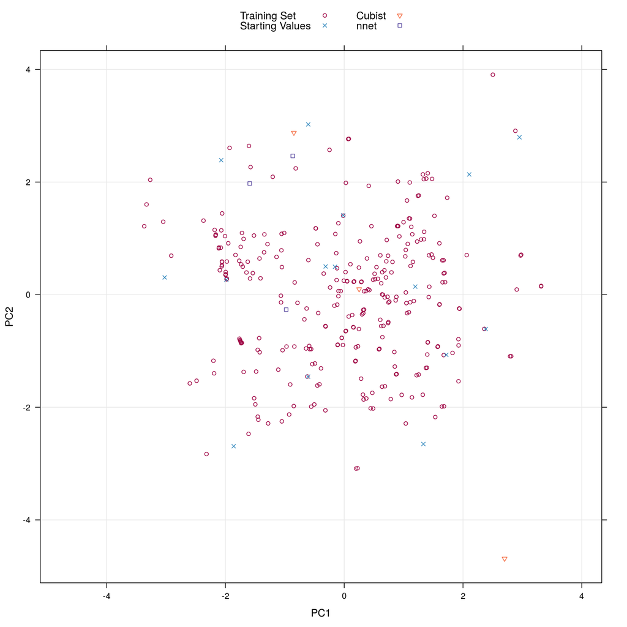

```r
# run PCA at 28 days
pp2 <- preProcess(age28Data[, 1:7], "pca")
# get the components for these mixtures
pca1 <- predict(pp2, age28Data[, 1:7])
pca1$Data <- "Training Set"
# Label which data points were used to start the searches
pca1$Data[startPoints] <- "Starting Values"

# Project the new mixtures in the same way (make sure to re-order columns)
pca3 <- predict(pp2, cubistResults[, names(age28Data[, 1:7])])
pca3$Data <- "Cubist"
pca4 <- predict(pp2, nnetResults[, names(age28Data[, 1:7])])
pca4$Data <- "nnet"

pcaData <- rbind(pca1, pca3, pca4)
pcaData$Data <- factor(pcaData$Data,
                       levels = c("Training Set", "Starting Values",
                                  "Cubist", "nnet"))

lim <- extendrange(pcaData[, 1:2])
xyplot(PC2 ~ PC1,
       data = pcaData,
       groups = Data,
       auto.key = list(columns = 2),
       xlim = lim,
       ylim = lim,
       type = c("g", "p"))
```